# Statistický model

## Modely ve vědě

## Sociologie a modely

- Sociální realita je složitá -> Potřeba zjednodušit
- Modely fungují ve vědě na více úrovních (teoretický model, statistický model)
- Model, pokus o definici: Reprezentace určitého aspektu světa založená na zjednodušujících předpokladech.

## Smysl modelu - užitečnost

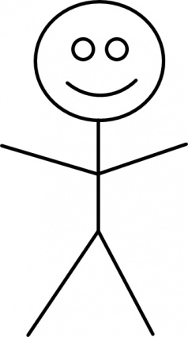

- “All models are wrong, but some are useful.”

## Příklady empirických modelů

- Wisdom of Crowds
- Tipping point
- Agent-based models …
- Statistické modely (např. lineární regrese)

## Statistický model

## Průměr jako nulový model

- nulový model - nemáme žádnou dodatečnou informaci
- 2 základní stavební kameny:
  - predikce modelu (v tomto případě aritmetický průměr)
  - odchylka od predikce (od modelu)

## Kategoriální prediktor

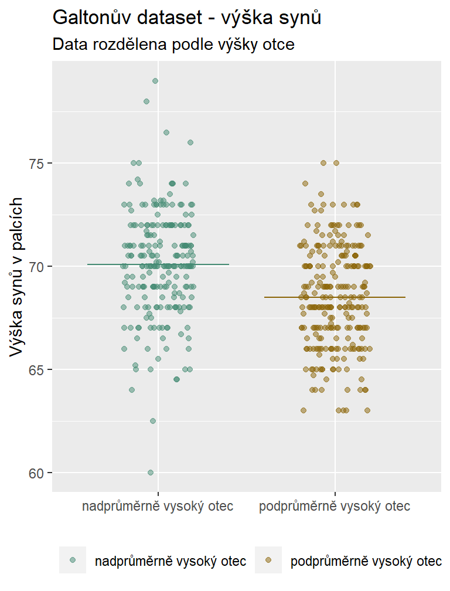

## Kardinální prediktor

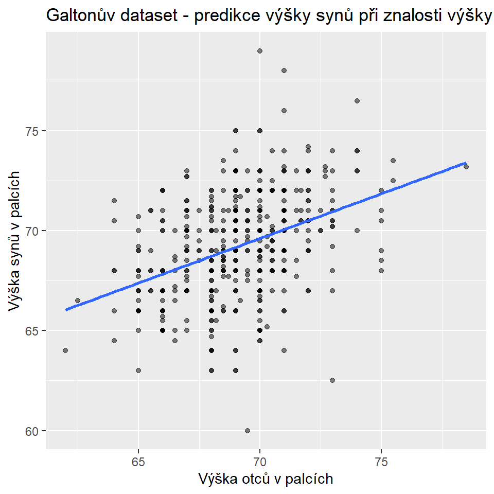

## Statistický model obecně

Statistický model má dva komponenty: deterministický komponent a náhodný komponent.

To můžeme vyjádřit takto:

Data = model + zbytek

Nebo alternativně takto:

Pozorování = predikovaná hodnota + chyba

## Průměr a regrese jako statistické modely

Formální zápis modelu s průměrem:

\[ y_i = \bar{y} + e_i \]

Formální zápis jednoduché lineární regrese:

\[ y_i = \beta_0 + \beta_1*x_i+e_i \]

- \(\beta_1\) (regresní koeficient) vyjadřuje sklon přímky,
- regresní koeficient v jednoduché lineární regresi: o kolik se podle našeho modelu zvedne podmíněná očekávaná hodnota závislé proměnné, když hodnota nezávislé proměnné vzroste o jednotku

## Očekávaná hodnota a podmíněná očekávaná hodnota

- Očekávaná hodnota (expectation) - průměr z velkého počtu nezávislých pozorování
- Podmíněná očekávaná hodnota - očekávaná hodnota závislé proměnné za předpokladu naplnění určitých podmínek

Podmíněná očekávaná hodnota v případě jednoduché lineární regrese: Průměrná hodnota závislé proměnné pro danou hodnotu nezávislé proměnné za předpokladu, že mezi nimi existuje lineární vztah.

Deterministická část modelu udává podmíněnou očekávanou hodnotu.

## Výstup lineární regrese v R a problém extrapolace

```
## (Intercept)      father
##  38.3625810   0.4465226
```

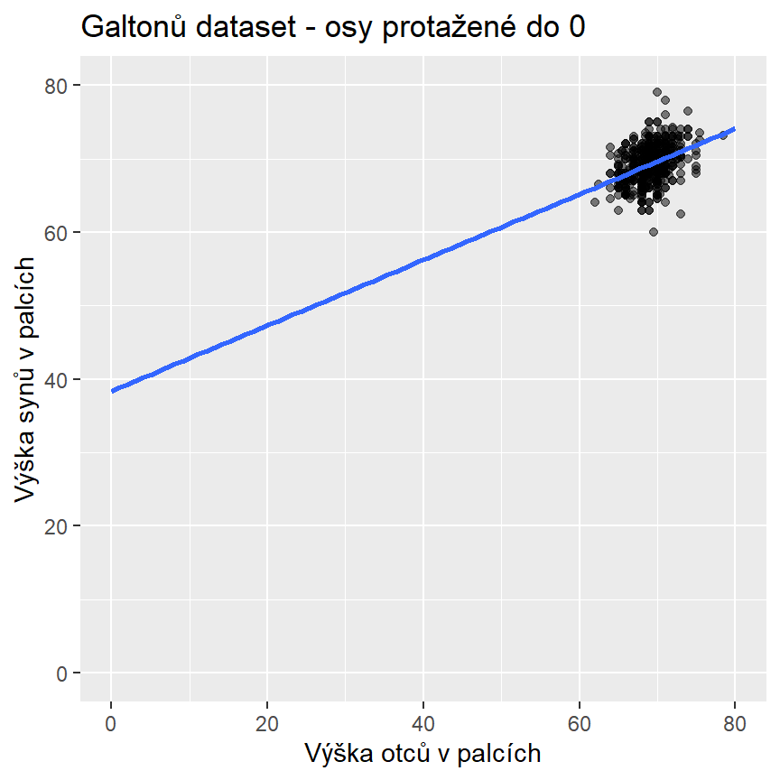

## Rozdíl mezi regresním a korelačním koeficientem

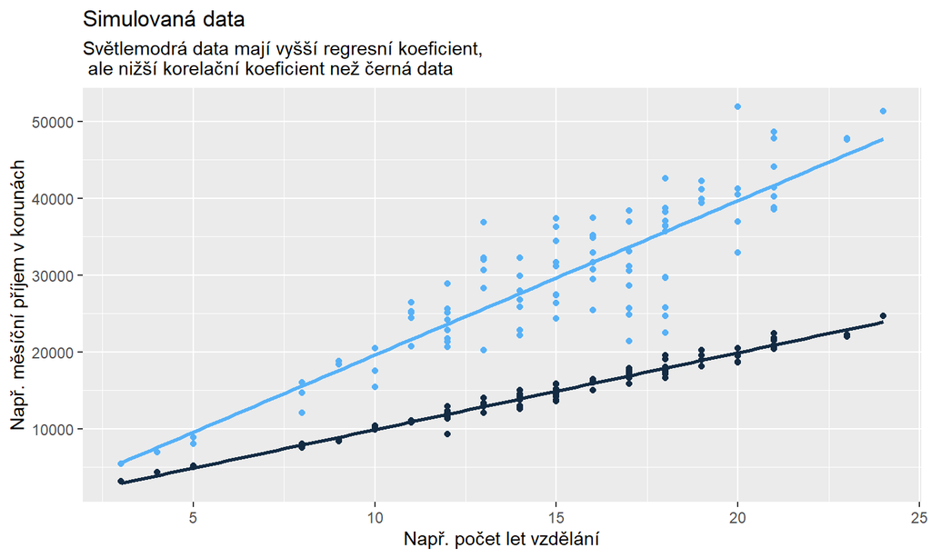

## Nadtavba: matematický vztah mezi regresním a korelačním koeficientem

\[ \beta_1 = \rho * (\sigma_y/\sigma_x) \]

Tedy regresní koeficient získáme z korelačního tak, že jej vynásobíme podílem směrodatné odchylky závislé proměnné a směrodatné odchylky nezávislé proměnné. Z toho vyplývá, že pokud je směrodatná odchylka obou proměnných stejná, oba koeficienty mají stejnou hodnotu.

## Statistický model a suma čtverců reziduí

## Minimalizace sumy reziduí

- Samotná komputace (odhadování) statistického modelu může probíhat různými způsoby. V případě lineární regrese používáme zpravidla algoritmus, který minimalizuje sumu čtverců odchylek (OLS)
- Suma čtverců v nulovém modelu:

\[ \sum{e_i^2} = \sum{(y_i-\bar{y})^2} \]

- Jaký je vztah mezi sumou čtverců reziduí a rozptylem?

## Rozklad sumy čtverců vizuálně

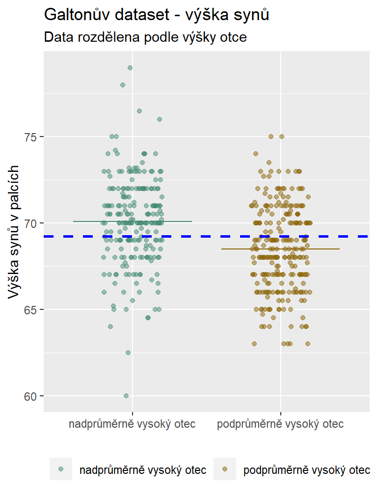

## Rozklad sumy čtverců koncepčně

Total SS = Explained SS + Residual SS

TSS = ESS + RSS

SST = SSE + SSR

## Rozklad sumy čtverců ve vzorcích

\[ TSS = \sum(y_i - \bar{y})^2 \]

\[ RSS = \sum(y_i - \hat{y_i})^2 \]

\[ ESS = \sum(\hat{y_i} - \bar{y})^2 \]

TSS = ESS + RSS

## Regrese k průměru

## Regrese k průměru

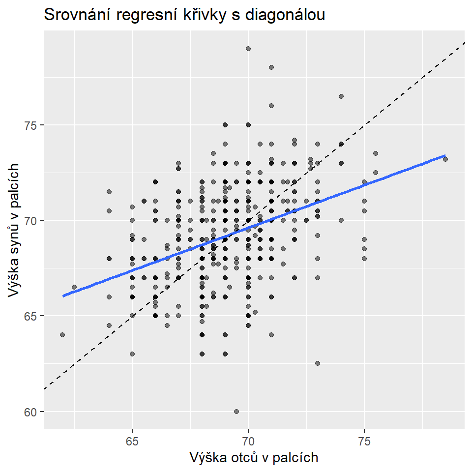

## Regrese k průměru je všude kolem nás

- Snižují rychlostní kamery počet nehod?
- Vede pochavala ke zhoršení?
- Proč mají nejúspěšnější země v testech PISA tendenci se v dalším kole zhoršovat?

## Výhled za hranice tohoto kurzu

## Vícenásobná linerární regrese

- Větší mnžství prediktorů

## Logistická regrese

- Kategoriální závislá proměnná

## Mechanistické modely

- Modeluje se nikoliv struktura vztahů (vyjádřená například přímkou v jednoduché lineární regresi), ale předpokládané chování

## Strojové učení (black-box algoritmy)

- Samotný odhad modelu zpravidla není zřejmý, používá se k predikci